# plan_of_analysis

Arielle Herman

2/11/2022

```r
#use_font("open-sans", "functions/css/open-sans.css")
poa <- wrangled %>% mutate(
  # demographics
  emp_status_b = case_when(
    str_detect(emp_b, "unemp") ~ "unemployed",
    str_detect(emp_b, "full|part|free|gig|small|home|student") ~ "employed",
    str_detect(emp_b, ";") ~ "multiple_other",
    TRUE ~ emp_b),
  emp_status_a = case_when(
    str_detect(emp_b, "unemp") ~ "unemployed",
    str_detect(emp_a, "full|part|free|gig|small|home|student") ~ "employed",
    str_detect(emp_a, ";") ~ "multiple_other",
    TRUE ~ emp_a),
  res_cat = labelled::to_character(res_type),
  res_cat = case_when(
    str_detect(res_cat, "public") ~ "public",
    str_detect(res_cat, "owner") ~ "owner",
    str_detect(res_cat, "renter") ~ "renter",
    str_detect(res_cat, "not have") ~ "no permanent residence",
    TRUE ~ res_cat),
  sch_level_cat = labelled::to_character(sch_level),
  sch_level_cat = case_when(
    str_detect(sch_level_cat, "high school|some college") ~ sch_level_cat,
    str_detect(sch_level_cat, "bach|ass") ~ "undergraduate degree",
    str_detect(sch_level_cat, "doct|mast|prof") ~ "graduate degree"
  ),
  age_cat = paste0(floor(age/10)*10, "s"),

  # hypotheses
  emp_change = emp_b != emp_a,
  # 1.4 inc_be_med_b
  # 1.5
  sch_bach = factor(ifelse(str_detect(labelled::to_character(sch_level), "(?<!no )degree"), "BA plus", labelled::to_character(sch_level))),
  # 1.6
  ins_has = factor(ifelse(!str_detect(ins, "do"), "has insurance", "doesn't have insurance")),
  # 1.7) People who were on private insurance were least likely to face changes in job status [14,15,21]
  # ins_prvt
  # 1.8)Higher paid employees (above median income) were less likely to return to working in-person [12,13,18]
  inc_ab_med = inc_a > 8 & inc_b > 8
  )

demographics <- c("borough", "age_cat", "gen", "not_eng", "mar",
                  "sch_level_cat", "hh_64_bi", "hh_ch_0_17_bi",
                  "inc_dist", "emp_status_b", "emp_status_a", "res_cat")
demographics <- setNames(demographics, demographics)
#hyps <- c("emp_change")
#dem <- "emp_status_b"
```

# 1.2) People who are currently unemployed who were not unemployed in before the pandemic (March 2020) [14&15]

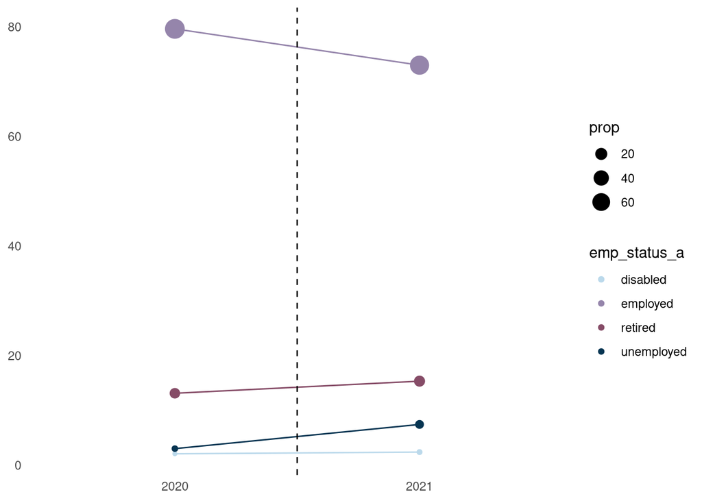

```r
# 1.2.1 Run distribution over population
poa %>% count(emp_status_b) %>% mutate(time = "2020") %>% rename(emp_status_a = emp_status_b) %>%
  bind_rows(count(poa, emp_status_a) %>% mutate(time = "2021")) %>%
  group_by(time) %>% mutate(prop = round(n/sum(n), digits = 4)*100) %>%
  filter(emp_status_a %in% c("disabled", "employed", "unemployed", "retired")) %>%
  ggplot(aes(x = time, y = prop, color = emp_status_a, group = emp_status_a)) +
  geom_point(aes(size = prop)) + geom_line(show.legend = FALSE) +
  xlab(NULL) + ylab(NULL) + geom_vline(xintercept = 1.5, lty = "dashed") +
  scale_color_manual(values = project_pal)
```

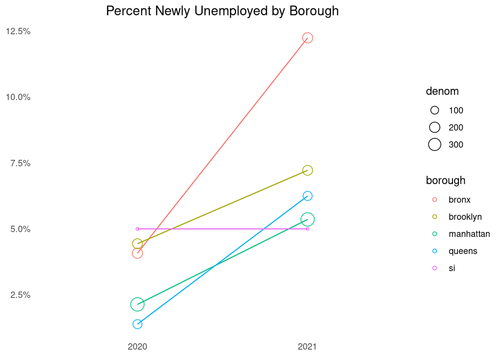

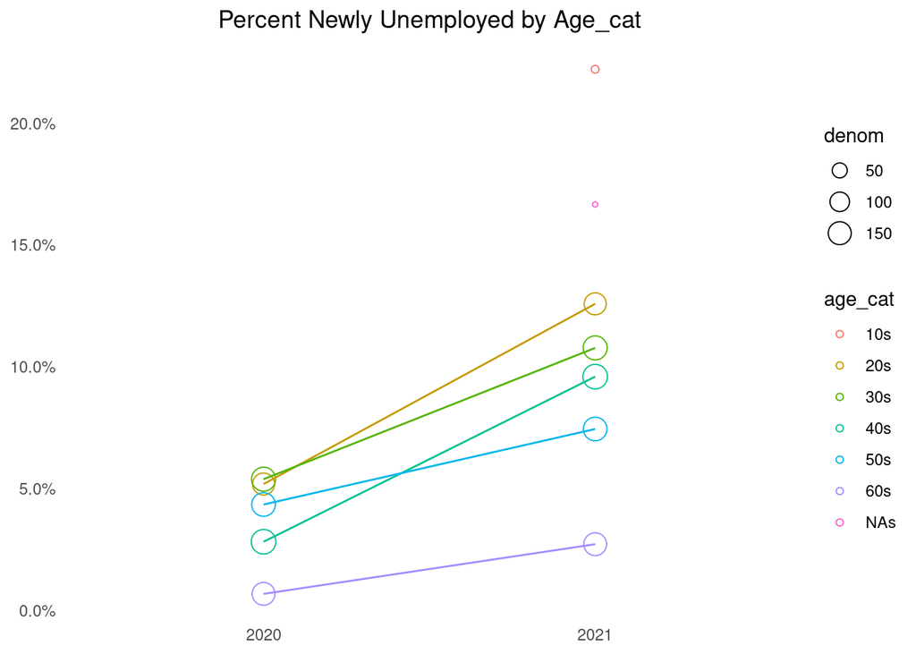

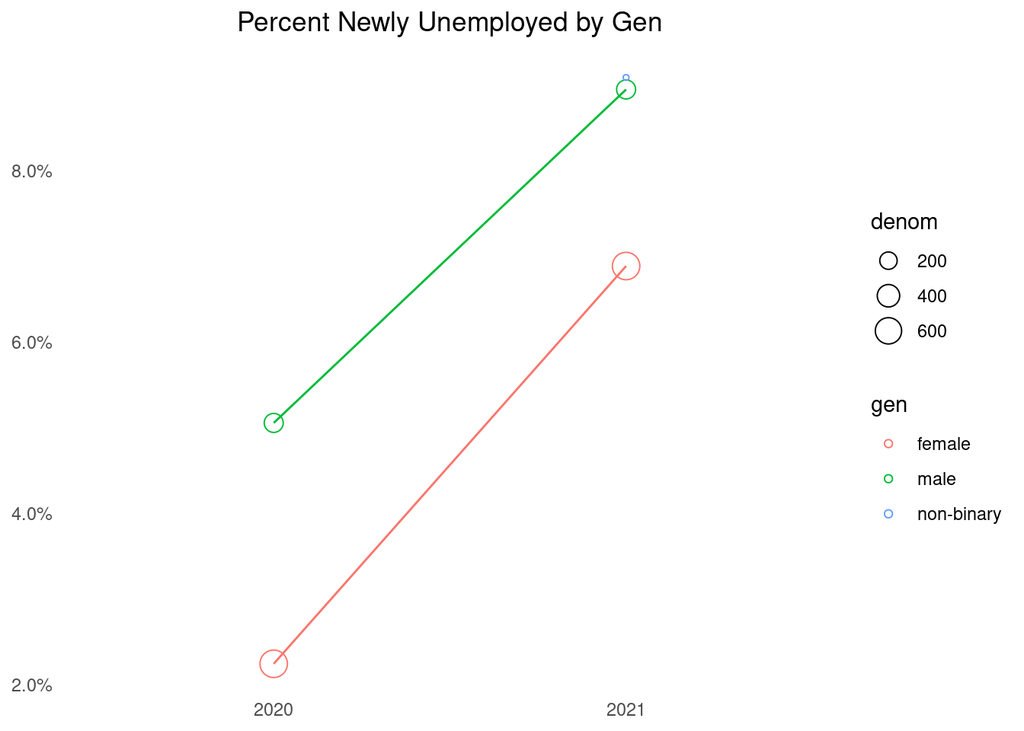

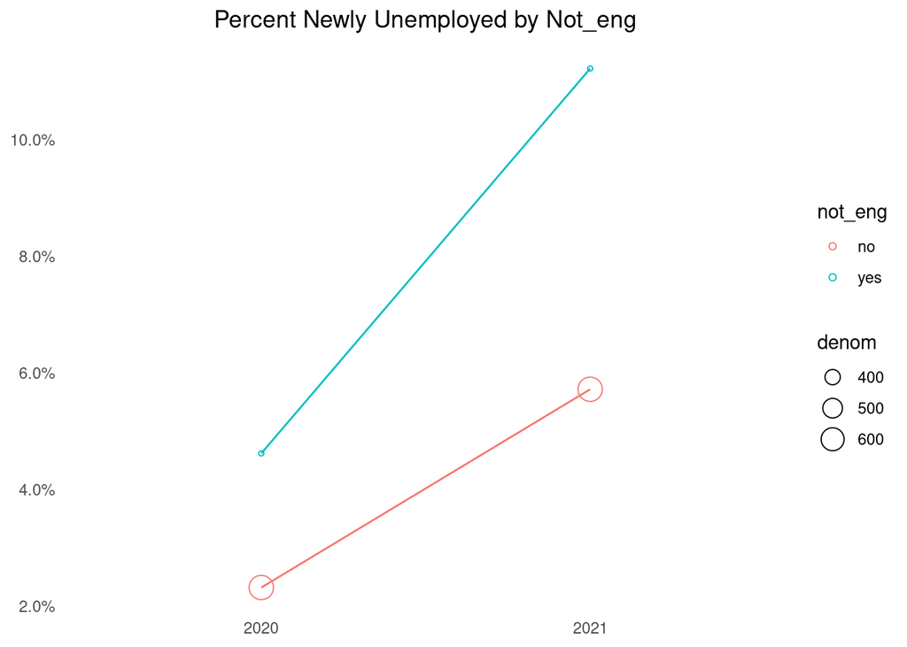

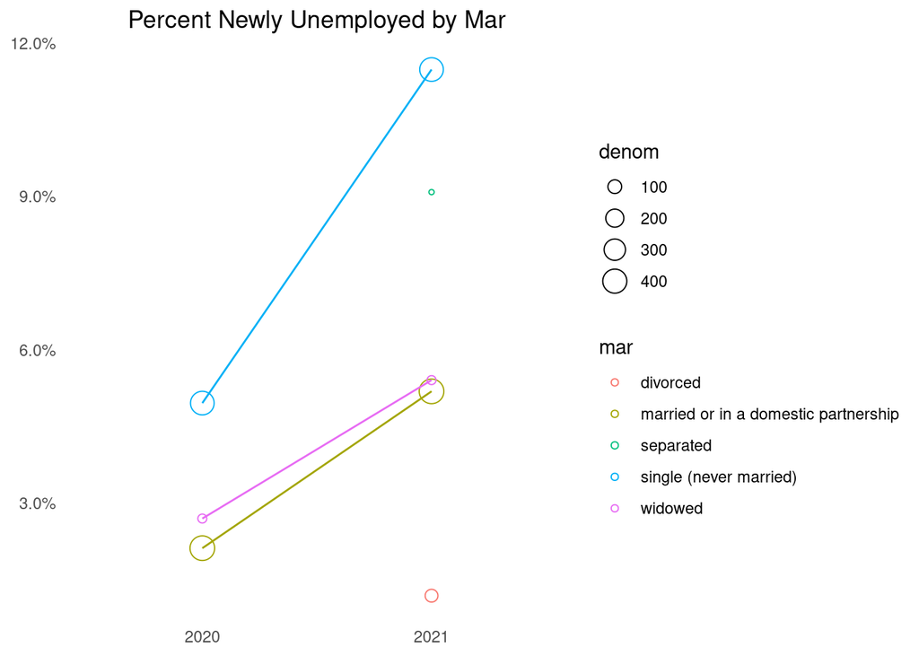

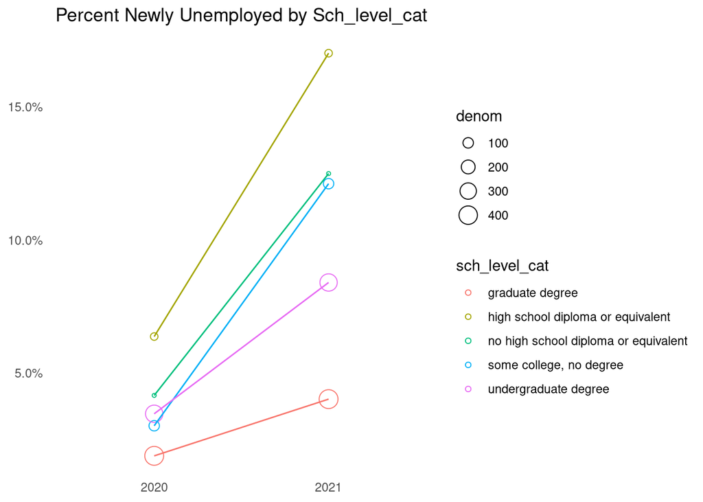

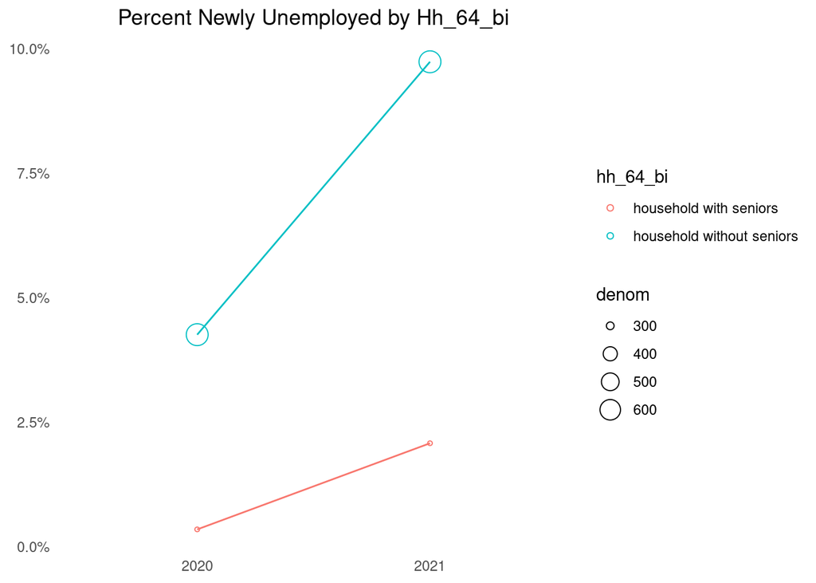

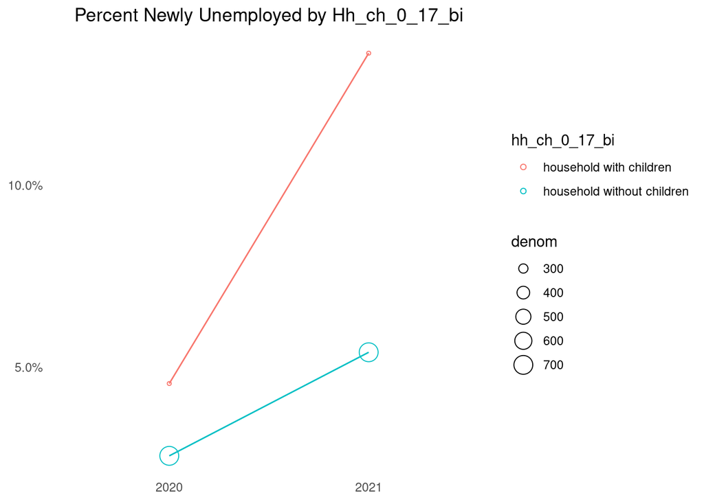

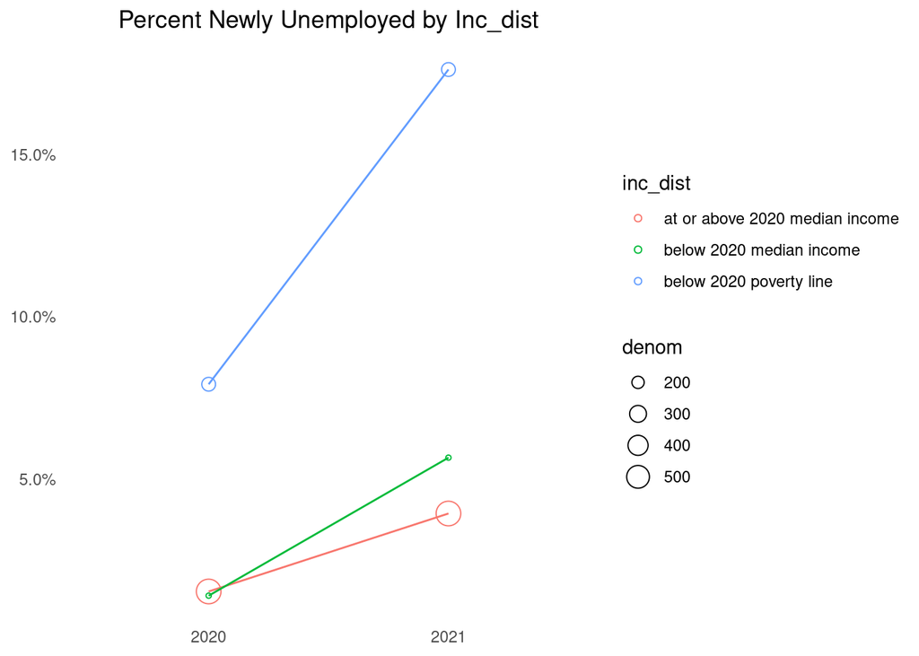

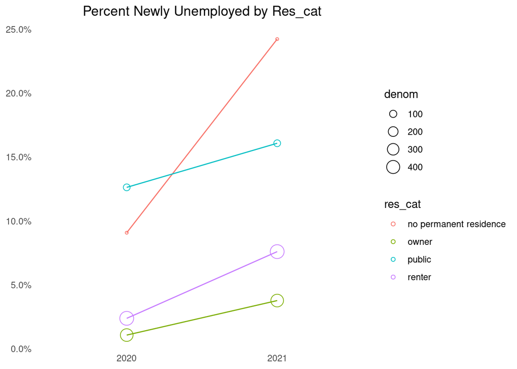

```r
# Run distribution by sub-demographics(a-k)
# two versions of the plots
dems_employment <- c(str_subset(demographics, "emp_status", negate = TRUE))
dems_employment <- setNames(dems_employment, dems_employment)

lapply(dems_employment, function(item) {
  sym_item <- sym(item)

  reshaped <- poa %>% count(dem = labelled::to_character(!!sym_item),
                            unemployed = emp_status_b == "unemployed") %>% mutate(time = "2020") %>%
    bind_rows(poa %>% count(dem = labelled::to_character(!!sym_item),
                            unemployed = emp_status_a == "unemployed") %>% mutate(time = "2021")) %>%
    group_by(time, dem) %>% mutate(denom = sum(n), prop = round(n/denom, digits = 4)) %>%
    filter(unemployed, !str_detect(dem, "prefer not"))

  plot <- reshaped %>% ggplot(aes(x = time, y = prop, color = dem, group = dem)) +
    geom_point(aes(size = denom), shape = 21) + geom_line(show.legend = FALSE) +
    scale_y_continuous(labels = scales::percent) +
    xlab(NULL) + ylab(NULL) + scale_color_discrete(guide = "legend", name = item) +
    ggtitle(glue::glue("Percent Newly Unemployed by {stringr::str_to_title(item)}")) + project_theme

  return(plot)

})
```

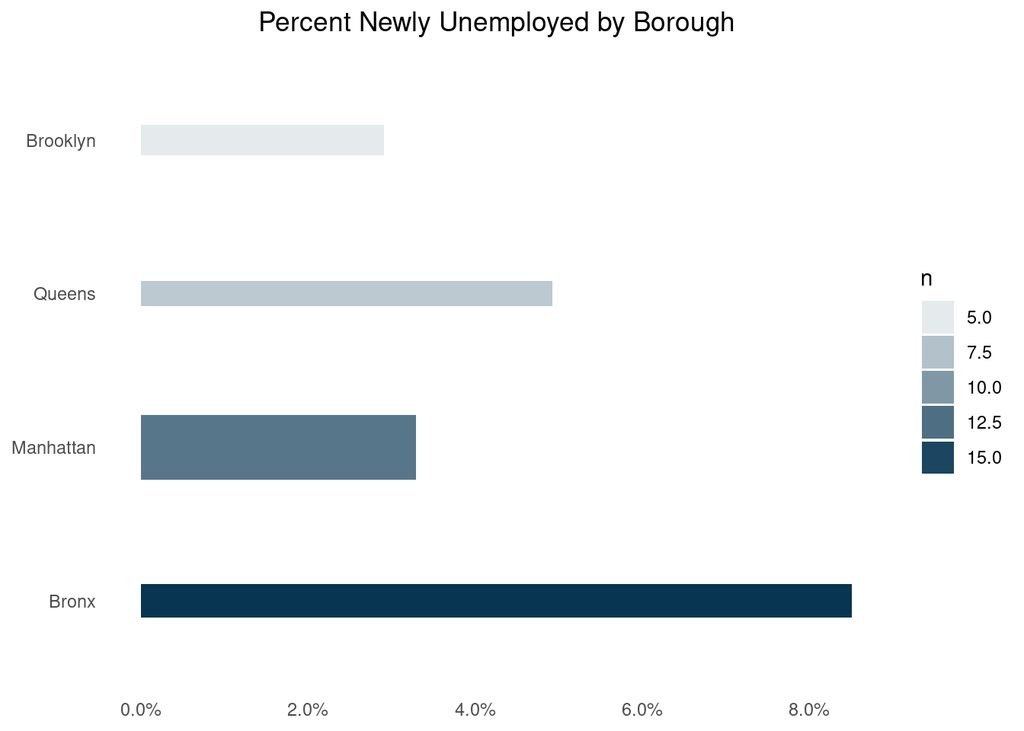

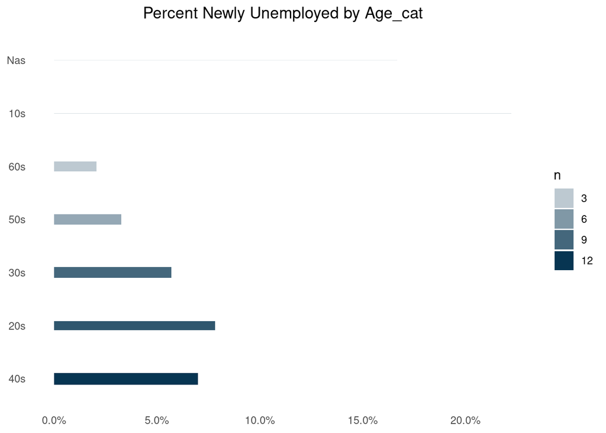

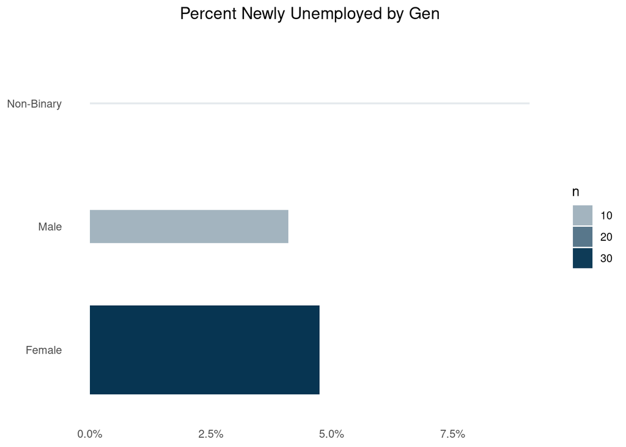

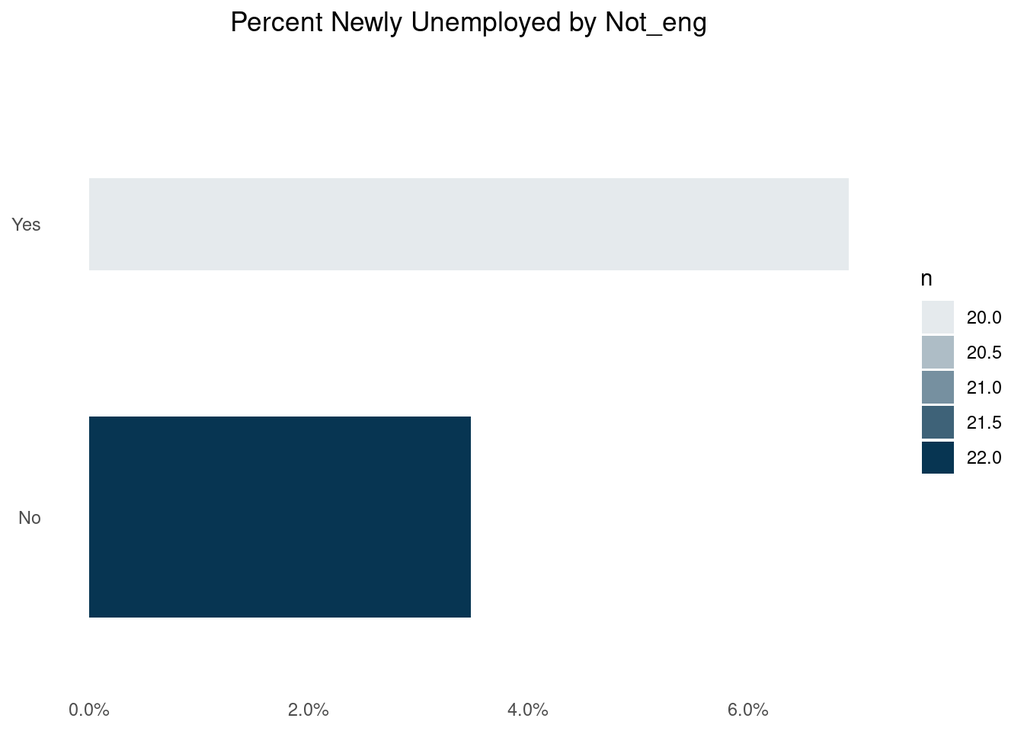

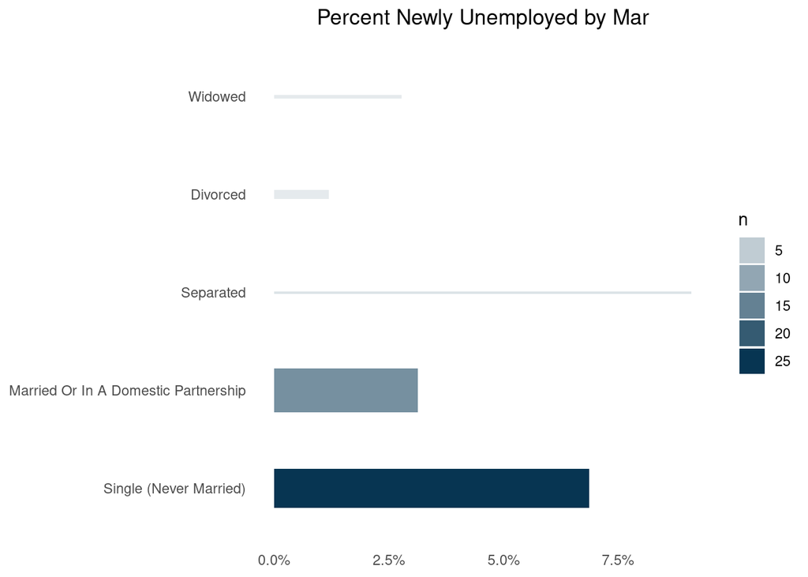

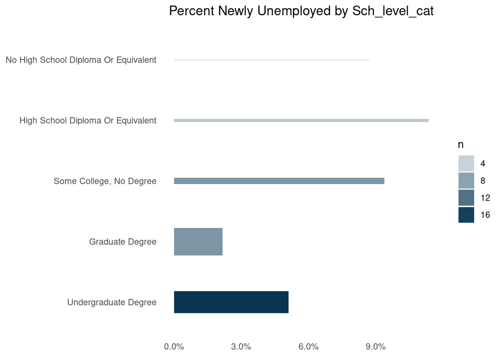

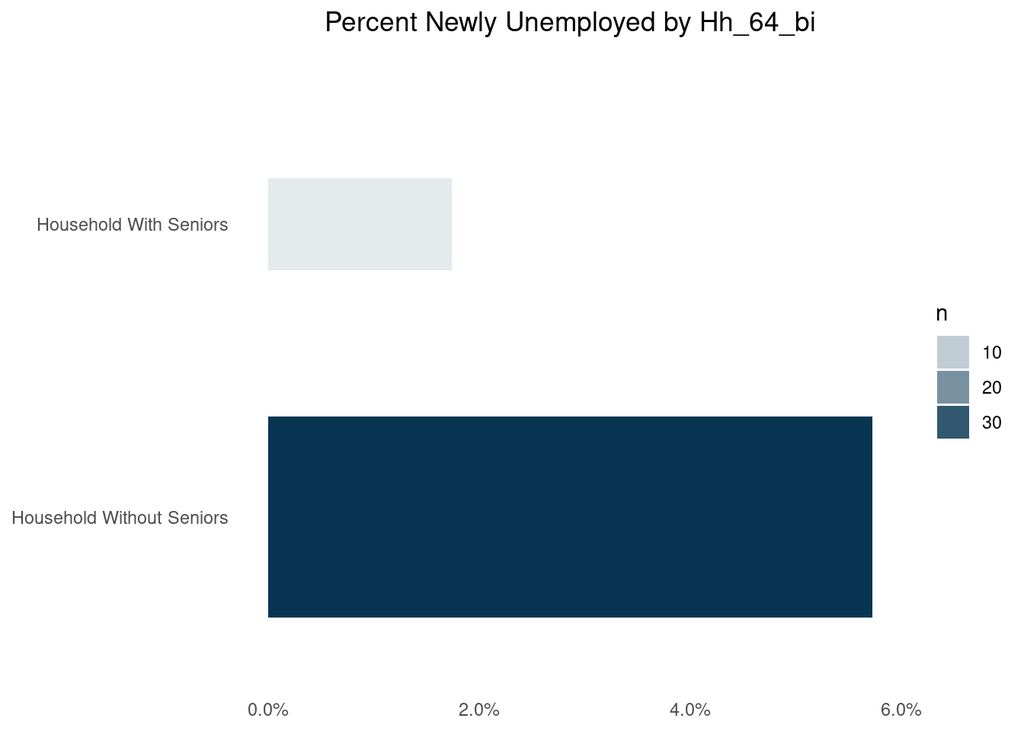

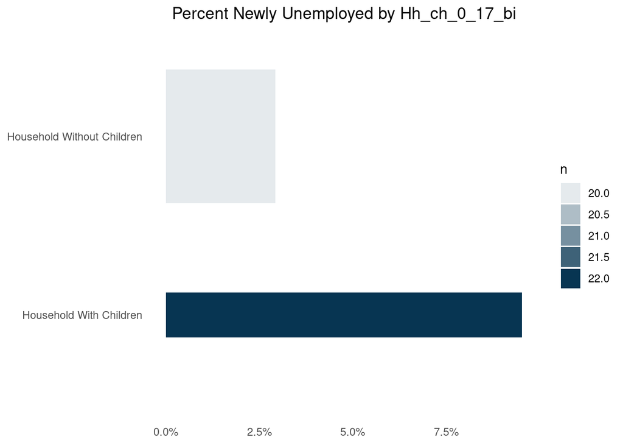

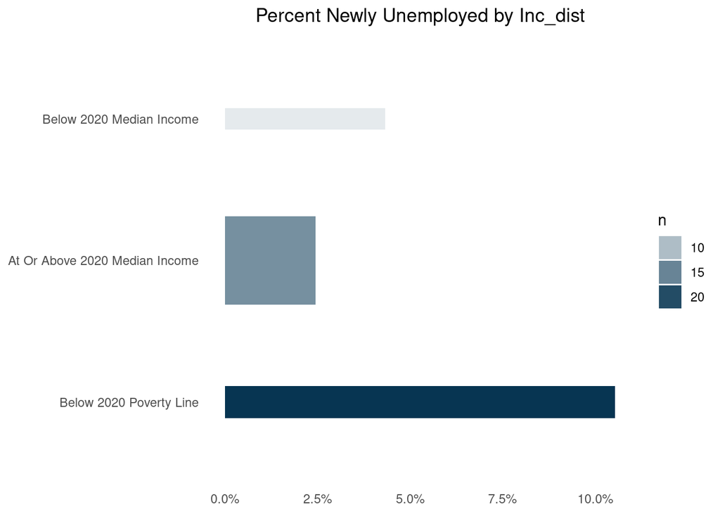

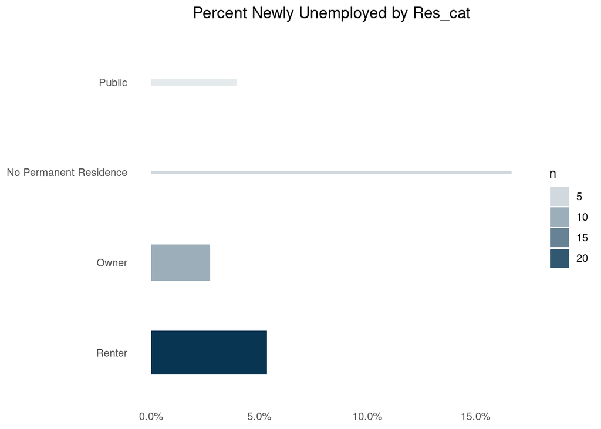

```r
lapply(setNames(dems_employment, dems_employment), function(item) {
  sym_item <- sym(item)

  reshaped <- poa %>% filter(!str_detect(emp_b, "unemp")) %>%
    count(!!sym_item, unemployed = emp_status_a == "unemployed") %>%
    group_by(!!sym_item) %>% mutate(prop = round(n/sum(n), digits = 4), denom = sum(n)) %>%
    filter(unemployed, !str_detect(!!sym_item, "prefer|;")) %>% ungroup %>% mutate(width = denom/sum(denom))
  plot <- reshaped %>% ggplot(aes(x = prop,
                                  y = reorder(stringr::str_to_title(labelled::to_character(!!sym_item)), -n), width = width, alpha = n)) +
      geom_col(fill = project_pal[4]) +
      scale_x_continuous(labels = scales::percent) +
      xlab(NULL) + ylab(NULL) + scale_color_discrete(guide = "legend", name = item) + ggtitle(item) +
    ggtitle(glue::glue("Percent Newly Unemployed by {stringr::str_to_title(item)}")) +
    project_theme

  return(plot)

})
```

# 1.3) Higher paid employees were less likely to face job status changes during the pandemic

```r
mean(poa$emp_change)
```

```
## [1] 0.2778947
```

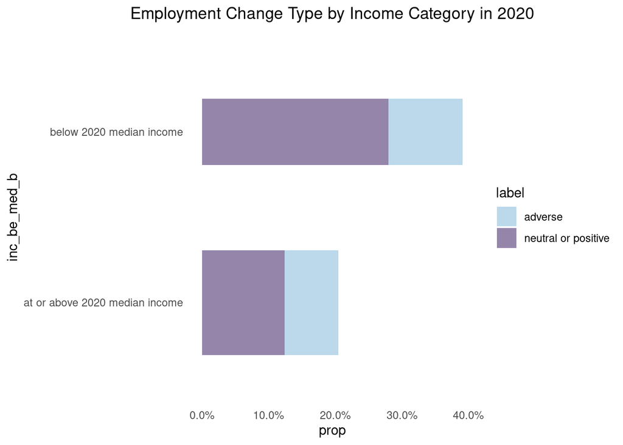

```r
poa %>%
  count(inc_be_med_b, emp_change, inc_neg) %>%
  group_by(inc_be_med_b) %>% mutate(denom = sum(n), prop = n/denom) %>%
  ungroup %>% mutate(width = denom/sum(n)) %>%
  filter(emp_change) %>% na.omit() %>%
  mutate_if(labelled::is.labelled, labelled::to_factor) %>%
  mutate(label = ifelse(str_detect(inc_neg, "neg"), "adverse", "neutral or positive")) %>%
  ggplot(aes(x = prop, y = inc_be_med_b, fill = label, width = width)) + geom_col() +
  ggtitle("Employment Change Type by Income Category in 2020") +
  scale_fill_manual(values = project_pal) +
  scale_x_continuous(label = scales::percent)
```

# 1.5-1.6)

1.5) People with at least a Bachelor’s degree were more/less likely to face job status changes during the pandemic [11, 14,15] 1.6) People who had insurance (any form) were less likely to face changes in job status [21,14,15]

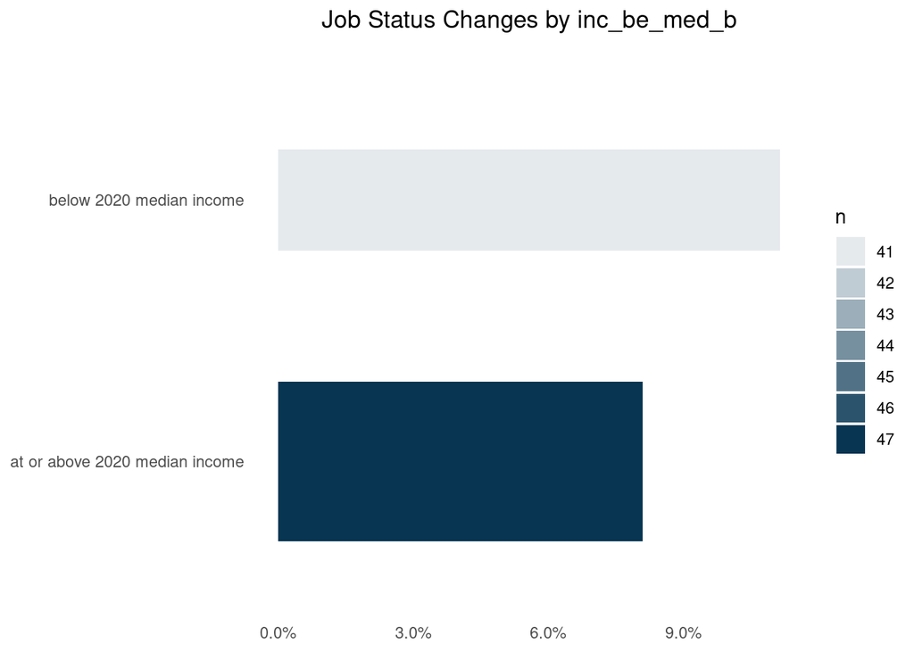

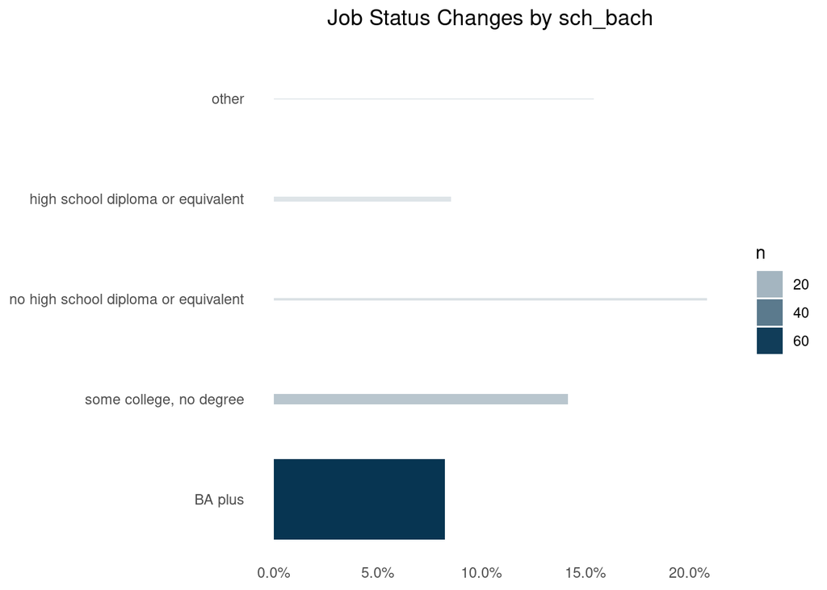

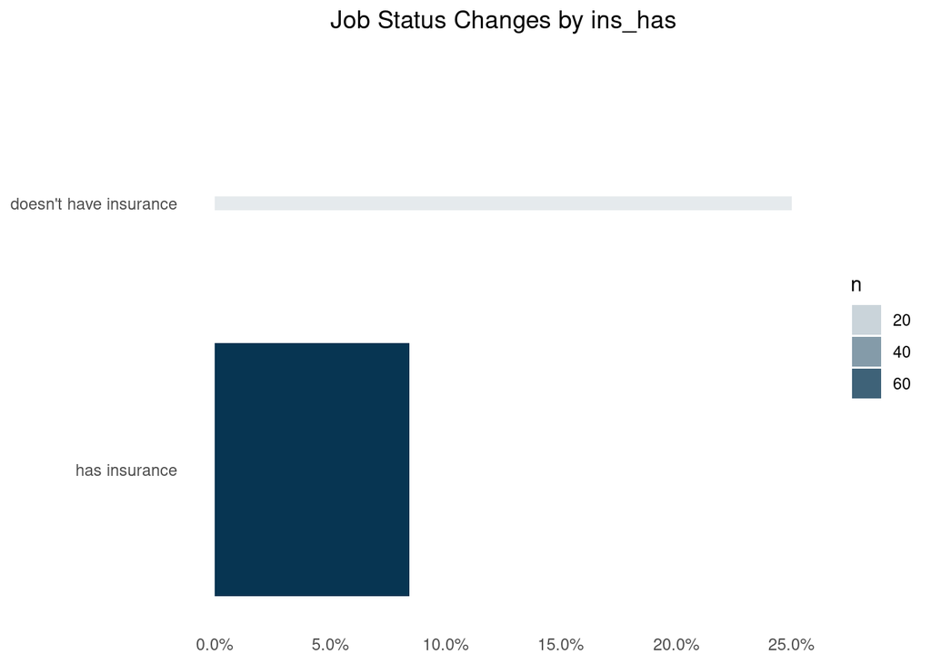

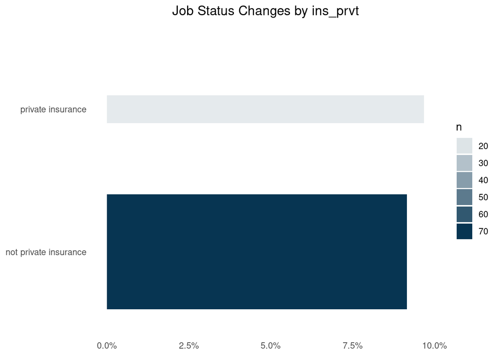

```r
#table(poa$ins[str_detect(poa$ins, ";")])
new_variables <- c("inc_be_med_b", "sch_bach", "ins_has", "ins_prvt")
new_variables <- setNames(new_variables, new_variables)

#item <- new_variables[[2]]

lapply(new_variables, function(item) {
  mean_val <- paste0(round(mean(str_detect(poa[[item]], "BA|has")), digits = 4)*100, "%")

  sym_item <- sym(item)

  reshaped <- poa %>% count(!!sym_item, emp_change, inc_neg) %>% group_by(!!sym_item) %>%
    mutate(denom = sum(n), prop = n/denom) %>% ungroup %>% mutate(width = denom/sum(n)) %>%
    filter(emp_change, inc_neg == 1) %>% na.omit() %>% mutate_if(labelled::is.labelled, labelled::to_character)

  plot <- reshaped %>% ggplot(aes(x = prop, y = reorder(!!sym_item, -n), width = width)) +
    geom_col(aes(alpha = n), fill = project_pal[4]) +
    #labs(subtitle = glue::glue("{mean_val} {levels(poa[[item]])[1]}")) +
    #geom_vline(xintercept = mean_val) +
    scale_x_continuous(label = scales::percent) + xlab(NULL) + ylab(NULL) +
    ggtitle(paste("Job Status Changes by", item))

  return(plot)
})
```

# 1.8, 1.13)

1.08) Higher paid employees (above median income) were less likely to return to working in-person [12,13,18] 1.13) Individuals with children were more likely to participate in hybrid work rather than full-time physical work

```
## $`proportion that returned to work virtually or hybridinc_ab_med_b`
```

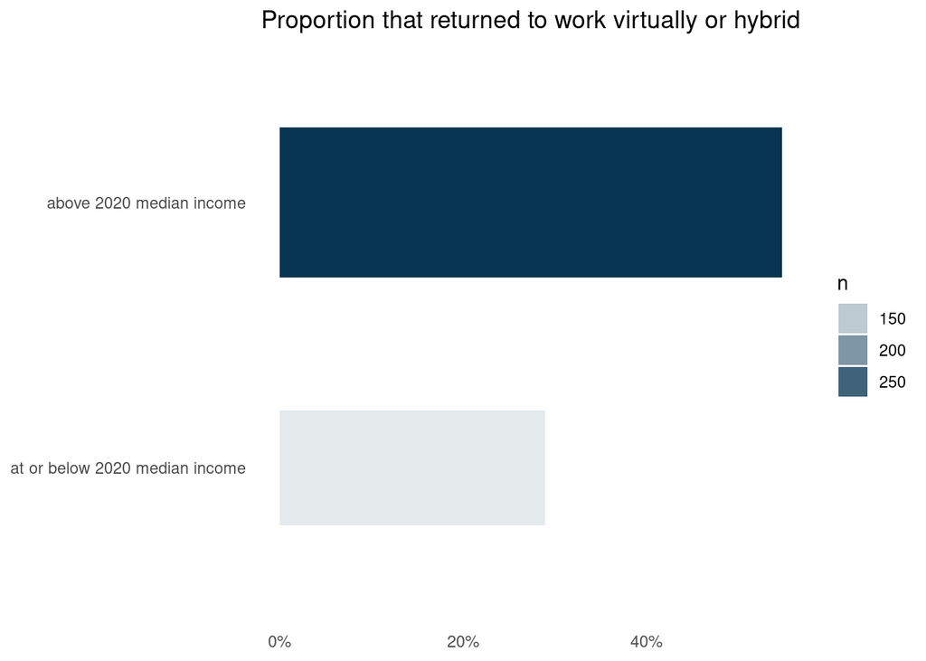

```
##
## $`proportion that returned to work virtually or hybridinc_be_med_b`
```

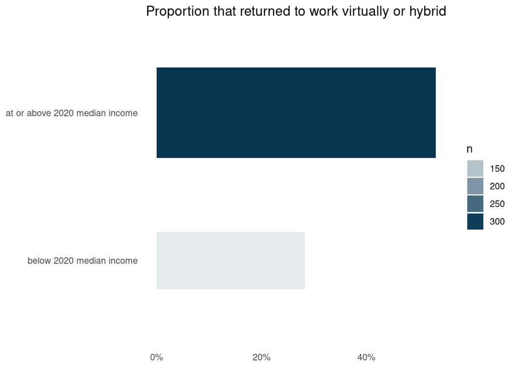

```
##
## $`proportion that returned to work virtually or hybridinc_dist`
```

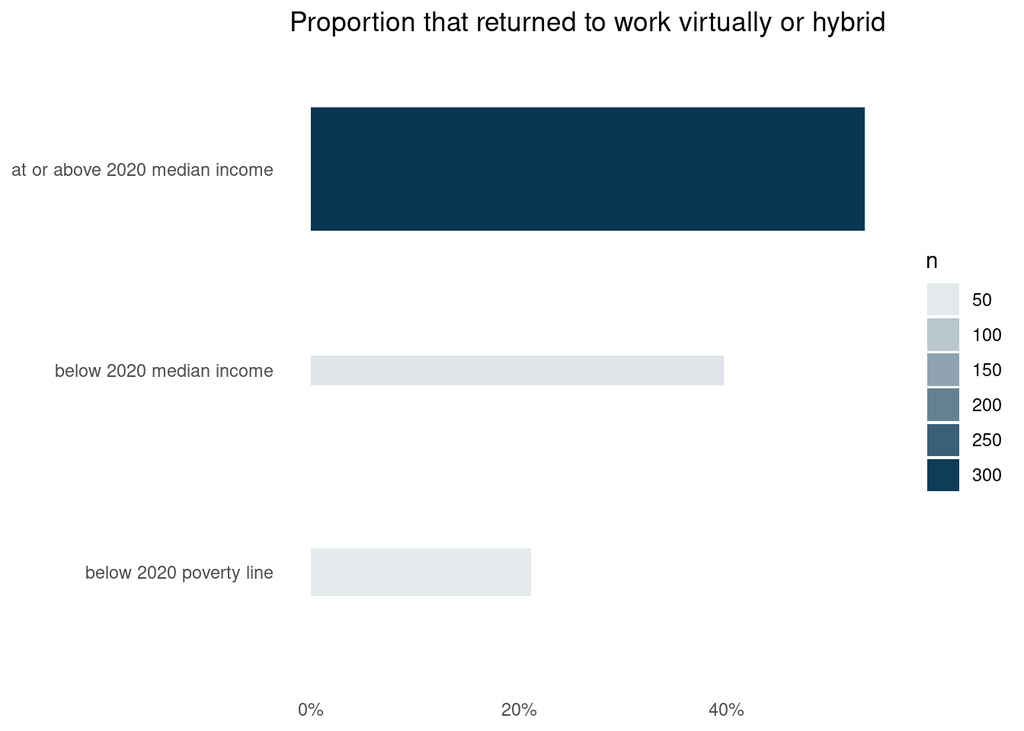

```
##
## $`proportion that returned to work virtually or hybridhh_ch_0_17_bi`
```

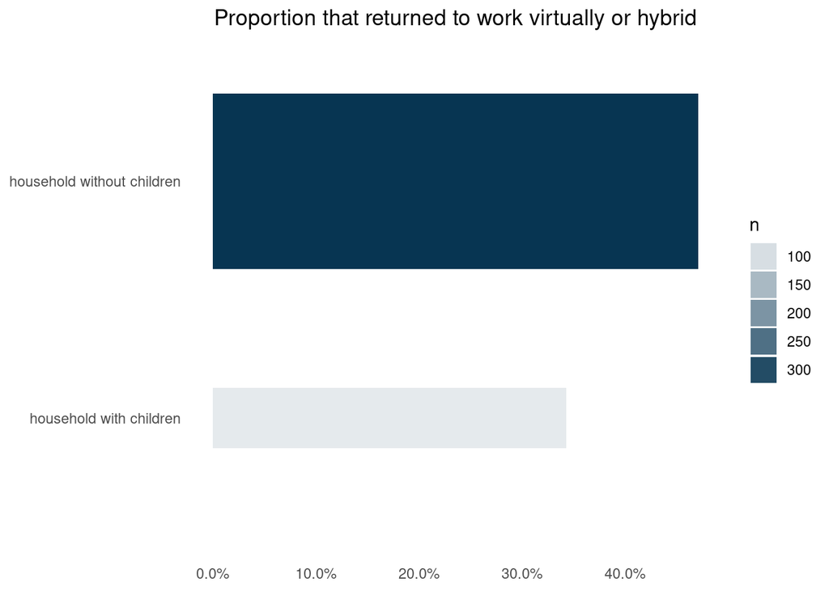

```r
# maybe we should make a variable that is all three categories (below, at above) or
inc_1.8 <- c("inc_ab_med_b", "inc_be_med_b", "inc_dist", "hh_ch_0_17_bi")
#item <- inc_1.8[[4]]

lapply(setNames(inc_1.8, paste0("proportion that returned to work virtually or hybrid", inc_1.8)), function(item) {
  sym_item <- sym(item)
  reshaped <- poa %>% count(!!sym_item, wrk_vi = wrk %in% c(2,3)) %>% group_by(!!sym_item) %>%
    mutate(denom = sum(n), prop = n/denom) %>% ungroup %>% mutate(width = denom/sum(n)) %>%
    filter(wrk_vi) %>%
    na.omit() %>% mutate_if(labelled::is.labelled, labelled::to_character)

  plot <- reshaped %>% ggplot(aes(x = prop, y = reorder(!!sym_item, n), width = width, alpha = n)) +
    geom_col(fill = project_pal[4]) +
    scale_x_continuous(label = scales::percent) + xlab(NULL) + ylab(NULL) +
    ggtitle("Proportion that returned to work virtually or hybrid")

  return(plot)
})
```

# 1.9-1.11)

1.09) People who are currently receiving unemployment benefits [16] - only 8 people who are currently recieving unemployment benefits

1.10) People who are unemployed and are not receiving unemployment benefits because they expired [15 &16]

```r
poa %>% count(unemp_ben) %>% mutate_if(labelled::is.labelled, labelled::to_character)
```

| unemp_ben | n |
| --- | --- |
| yes | 8 |
| no, because they expired | 22 |
| no, but i tried to apply for benefits | 10 |
| no, but i did not try to apply for benefits | 22 |
| NA | 888 |

```r
poa %>% count(emp_a_un, unemp_expired = unemp_ben == 2)
```

| emp_a_un | unemp_expired | n |
| --- | --- | --- |
| 0 | NA | 888 |
| 1 | FALSE | 40 |
| 1 | TRUE | 22 |

```r
dems_unemp <- str_subset(demographics, "un|emp", negate = TRUE)
dems_unemp <- setNames(dems_unemp, dems_unemp)

poa %>% count(unemp_ben) %>% mutate(label = labelled::to_factor(unemp_ben))
```

| unemp_ben | n | label |
| --- | --- | --- |
| 1 | 8 | yes |
| 2 | 22 | no, because they expired |
| 3 | 10 | no, but i tried to apply for benefits |
| 4 | 22 | no, but i did not try to apply for benefits |
| NA | 888 | NA |